```python
import pandas as pd
from sklearn import preprocessing
import sklearn.preprocessing as sp
from sklearn.tree import DecisionTreeClassifier
from sklearn.metrics import accuracy_score,precision_recall_curve,auc,f1_score,roc_auc_score,confusion_matrix,roc_curve
from sklearn.model_selection import train_test_split
from sklearn.model_selection import cross_val_score
from scipy import stats as ss
import math
import numpy as np
```

# Data Import and Data Engineering

1. Load the data
2. The number of value counts for matched transaction id and feature transaction id
3. Label the data and create a new column For eg if matched transaction id and feature transaction id matching then is_success as "yes" else "no"
4. Remove all Id columns which is not required for models

```python
df_input=pd.read_csv("./data_interview_test.csv" ,sep=":")
```

```python
df_input[["matched_transaction_id","feature_transaction_id"]].value_counts()
```

```
matched_transaction_id  feature_transaction_id
50,408                  50,413                    1
20,455                  20,004                    1
                        20,014                    1
                        20,013                    1
                        20,012                    1
                                                 ..
30,956                  30,159                    1
                        30,158                    1
                        30,139                    1
                        30,137                    1
10,112                  10,108                    1
Length: 12034, dtype: int64
```

```python
#"Yes" if matched_transaction_id and feature_transaction_id matches else "No".
df_input['is_success'] = df_input.apply(lambda x: "yes" if x['matched_transaction_id'] ==
                     x['feature_transaction_id']  else "No", axis=1)
```

```python
final_df=df_input.drop(["matched_transaction_id","feature_transaction_id","receipt_id","company_id"],axis=1)
```

```python
#Label encode the dependent variable
label_encoder = preprocessing.LabelEncoder()
final_df['is_success']= label_encoder.fit_transform(df_input['is_success'])
df_input['is_success']= label_encoder.fit_transform(df_input['is_success'])
print(final_df["is_success"].value_counts())
```

```
0    11177
1      857
Name: is_success, dtype: int64
```

# Apply the base model and see how it behaves

1. Applied Decesion tree as the dimesion is less and lot of value ranges are less in data
2. As It's imbalance dataset we shouldn't consider Accuracy as metrics.
3. Can calculate ROC-AUC,F1 score or Precesion-Recall graph for our validation

```python
#Apply the base model and see the result
ohe = sp.OneHotEncoder()

X = final_df.drop(['is_success'],axis=1)
y = final_df['is_success']

# X.drop(["Age","Duration"],axis=1,inplace=True)
# print(y.columns)

ohe.fit(X)
X = ohe.transform(X).toarray()
# from imblearn.over_sampling import SMOTE
# oversample = SMOTE()
# X, y = oversample.fit_resample(X, y)
X_train, X_test, y_train, y_test = train_test_split(X, y, test_size=0.3, random_state=42)
# x_train=X_train.drop(["matched_transaction_id","feature_transaction_id"],axis=1)
# x_test=X_test.drop(["matched_transaction_id","feature_transaction_id"],axis=1)
for i in range(1,8):
    tree = DecisionTreeClassifier(max_depth=i, random_state=42)
    tree.fit(X_train,y_train)
    y_pred = tree.predict(X_test)
    ns_probs = [0 for _ in range(len(y_test))]
    print(f"the roc-auc score is for tree depth {i}---", roc_auc_score(y_test,y_pred))
cf_matrix = confusion_matrix(y_test, y_pred)

print(cf_matrix)
```

```
the roc-auc score is for tree depth 1--- 0.5
the roc-auc score is for tree depth 2--- 0.6162304345150313
the roc-auc score is for tree depth 3--- 0.6884509218884981
the roc-auc score is for tree depth 4--- 0.7805862066607555
the roc-auc score is for tree depth 5--- 0.8071544656146644
the roc-auc score is for tree depth 6--- 0.8023250645629663
the roc-auc score is for tree depth 7--- 0.8007152642124002
[[3318   31]
 [ 102  160]]
```

```
No Skill: ROC AUC=0.500
Decesion Tree: ROC AUC=0.945
```

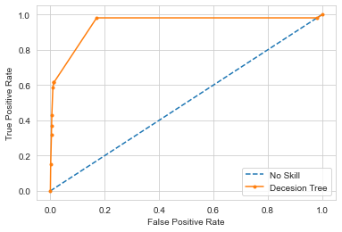

```python
from sklearn.metrics import roc_curve
from matplotlib import pyplot as plt
ns_probs = [0 for _ in range(len(y_test))]
lr_probs = tree.predict_proba(X_test)
lr_probs = lr_probs[:, 1]
# calculate scores
ns_auc = roc_auc_score(y_test, ns_probs)
lr_auc = roc_auc_score(y_test, lr_probs)
# summarize scores
print('No Skill: ROC AUC=%.3f' % (ns_auc))
print('Decesion Tree: ROC AUC=%.3f' % (lr_auc))
# calculate roc curves
ns_fpr, ns_tpr, _ = roc_curve(y_test, ns_probs)
lr_fpr, lr_tpr, _ = roc_curve(y_test, lr_probs)
# plot the roc curve for the model
plt.plot(ns_fpr, ns_tpr, linestyle='--', label='No Skill')
plt.plot(lr_fpr, lr_tpr, marker='.', label='Decesion Tree')
# axis labels
plt.xlabel('False Positive Rate')
plt.ylabel('True Positive Rate')
# show the legend
plt.legend()
# show the plot
plt.show()
```

```
Decesion Tree: f1=0.706 auc=0.772
```

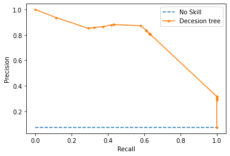

```python
lr_precision, lr_recall, _ = precision_recall_curve(y_test, lr_probs)
lr_f1, lr_auc = f1_score(y_test, y_pred), auc(lr_recall, lr_precision)
# summarize scores
print('Decesion Tree: f1=%.3f auc=%.3f' % (lr_f1, lr_auc))
# plot the precision-recall curves
no_skill = len(y_test[y_test==1]) / len(y_test)
plt.plot([0, 1], [no_skill, no_skill], linestyle='--', label='No Skill')
plt.plot(lr_recall, lr_precision, marker='.', label='Decesion tree')
# axis labels
plt.xlabel('Recall')
plt.ylabel('Precision')
# show the legend
plt.legend()
# show the plot
plt.show()
```

# Exploratory Data Analysis

[figure not shown]

```python
import seaborn as sns
sns.set_style("whitegrid");
sns.pairplot(df_input, hue="is_success", size=2);
plt.show()
```

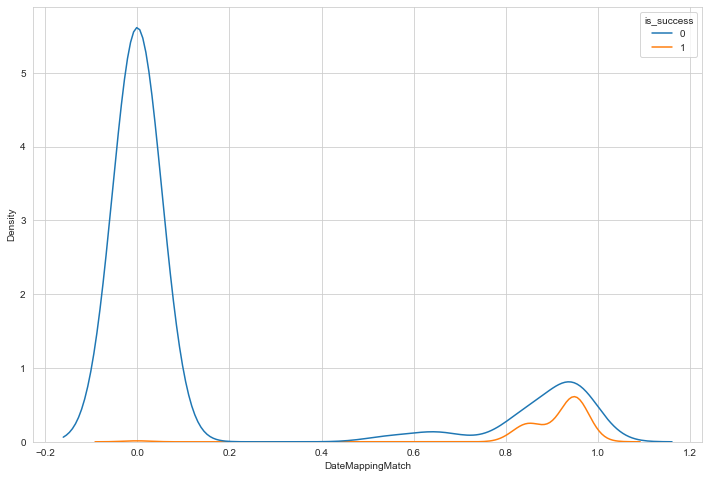

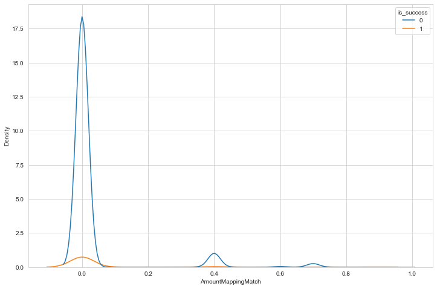

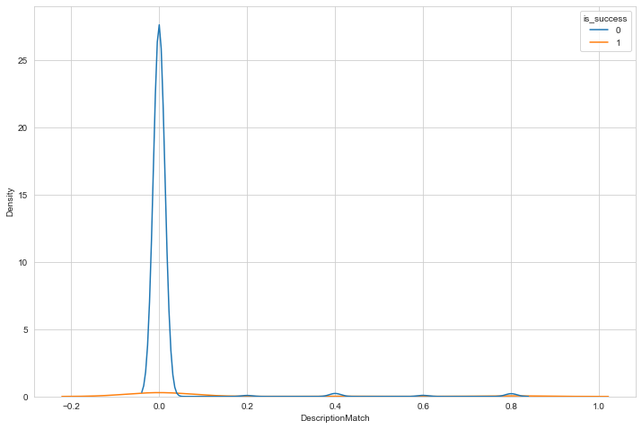

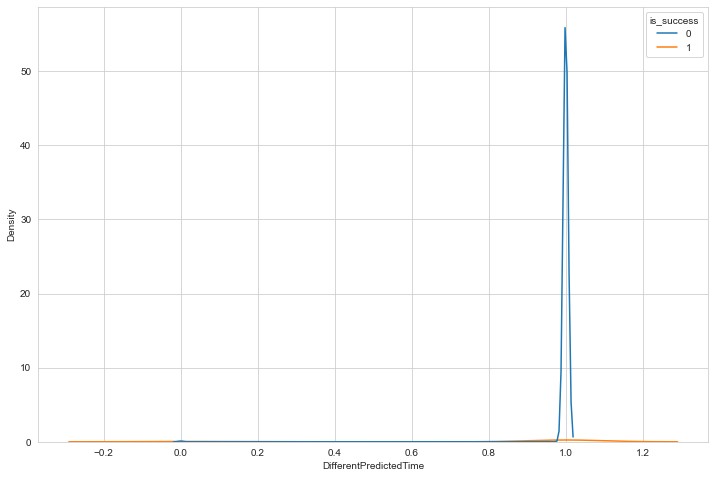

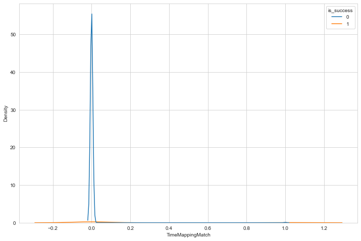

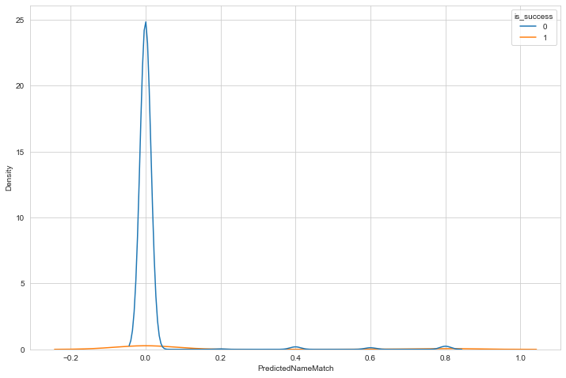

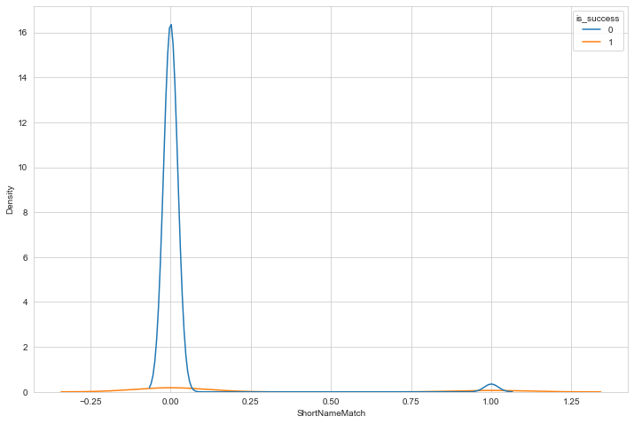

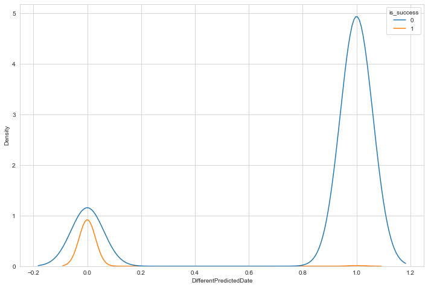

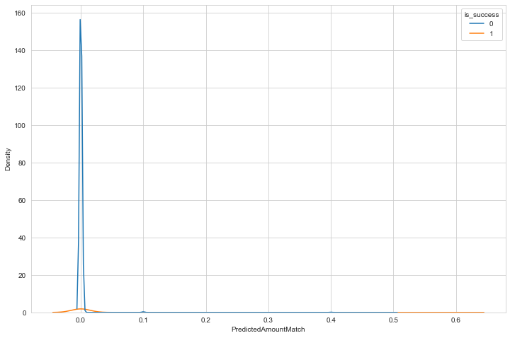

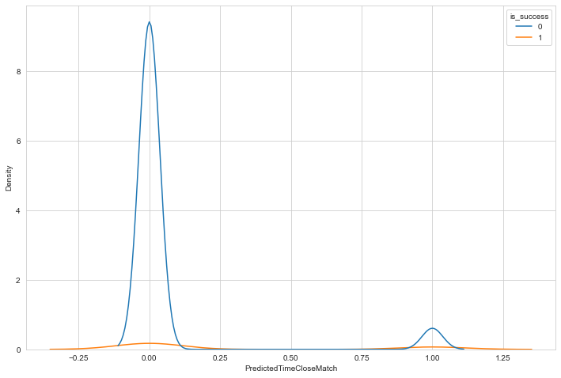

```python
for col in final_df.columns.tolist():
    if col!="is_success":
        plt.figure(figsize=(12,8))
        sns.kdeplot(data=final_df,x=col,hue='is_success')
```

# Multicolinearity and cross entropy check

1. Heatmap to see if any multicolinear features available
2. Remove one feature if the features are multicolinear
3. Cross entropy check between feature and target
4. More cross entropy better to remove the feature

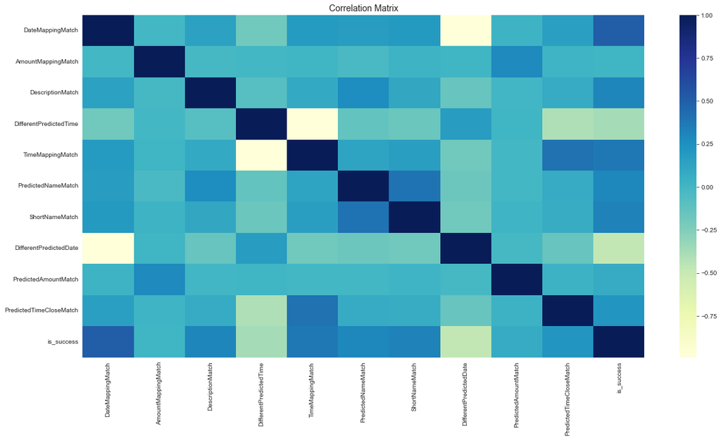

```python
fig, ax = plt.subplots(figsize=(20,10))
# Imbalanced DataFrame Correlation
corr = final_df.corr()
sns.heatmap(corr, cmap='YlGnBu', annot_kws={'size':30}, ax=ax)
ax.set_title("Correlation Matrix", fontsize=14)
plt.show()
```

```python
final_df.corr()
```

|  | DateMappingMatch | AmountMappingMatch | DescriptionMatch | DifferentPredictedTime | TimeMappingMatch | PredictedNameMatch | ShortNameMatch | DifferentPredictedDate | PredictedAmountMatch | PredictedTimeCloseMatch | is_success |
| --- | --- | --- | --- | --- | --- | --- | --- | --- | --- | --- | --- |
| DateMappingMatch | 1.000000 | -0.008016 | 0.148044 | -0.189589 | 0.190991 | 0.181834 | 0.196076 | -0.990860 | 0.020592 | 0.155376 | 0.495295 |
| AmountMappingMatch | -0.008016 | 1.000000 | -0.014947 | -0.008440 | 0.007606 | -0.031537 | 0.026491 | 0.010701 | 0.287053 | 0.016421 | 0.009137 |
| DescriptionMatch | 0.148044 | -0.014947 | 1.000000 | -0.086593 | 0.093542 | 0.265744 | 0.104109 | -0.147950 | 0.002102 | 0.078492 | 0.305888 |
| DifferentPredictedTime | -0.189589 | -0.008440 | -0.086593 | 1.000000 | -0.987785 | -0.127711 | -0.161234 | 0.181536 | 0.005852 | -0.407039 | -0.370068 |
| TimeMappingMatch | 0.190991 | 0.007606 | 0.093542 | -0.987785 | 1.000000 | 0.125658 | 0.162474 | -0.182699 | -0.005925 | 0.401384 | 0.373170 |
| PredictedNameMatch | 0.181834 | -0.031537 | 0.265744 | -0.127711 | 0.125658 | 1.000000 | 0.395011 | -0.173544 | -0.008117 | 0.077021 | 0.295999 |
| ShortNameMatch | 0.196076 | 0.026491 | 0.104109 | -0.161234 | 0.162474 | 0.395011 | 1.000000 | -0.186434 | 0.018191 | 0.068922 | 0.324105 |
| DifferentPredictedDate | -0.990860 | 0.010701 | -0.147950 | 0.181536 | -0.182699 | -0.173544 | -0.186434 | 1.000000 | -0.018367 | -0.150141 | -0.475173 |
| PredictedAmountMatch | 0.020592 | 0.287053 | 0.002102 | 0.005852 | -0.005925 | -0.008117 | 0.018191 | -0.018367 | 1.000000 | 0.035304 | 0.077648 |
| PredictedTimeCloseMatch | 0.155376 | 0.016421 | 0.078492 | -0.407039 | 0.401384 | 0.077021 | 0.068922 | -0.150141 | 0.035304 | 1.000000 | 0.216837 |
| is_success | 0.495295 | 0.009137 | 0.305888 | -0.370068 | 0.373170 | 0.295999 | 0.324105 | -0.475173 | 0.077648 | 0.216837 | 1.000000 |

```python
class MultiCollinearityEliminator():

    #Class Constructor
    def __init__(self, df, target, threshold):
        self.df = df
        self.target = target
        self.threshold = threshold

    #Method to create and return the feature correlation matrix dataframe
    def createCorrMatrix(self, include_target = False):
        #Checking we should include the target in the correlation matrix
        if (include_target == False):
            df_temp = self.df.drop([self.target], axis =1)

            #Setting method to Pearson to prevent issues in case the default method for df.corr() gets changed
            #Setting min_period to 30 for the sample size to be statistically significant (normal) according to
            #central limit theorem
            corrMatrix = df_temp.corr(method='pearson', min_periods=30).abs()
        #Target is included for creating the series of feature to target correlation - Please refer the notes under the
        #print statement to understand why we create the series of feature to target correlation
        elif (include_target == True):
            corrMatrix = self.df.corr(method='pearson', min_periods=30).abs()
        return corrMatrix

    #Method to create and return the feature to target correlation matrix dataframe
    def createCorrMatrixWithTarget(self):
        #After obtaining the list of correlated features, this method will help to view which variables
        #(in the list of correlated features) are least correlated with the target
        #This way, out the list of correlated features, we can ensure to elimate the feature that is
        #least correlated with the target
        #This not only helps to sustain the predictive power of the model but also helps in reducing model complexity

        #Obtaining the correlation matrix of the dataframe (along with the target)
        corrMatrix = self.createCorrMatrix(include_target = True)
        #Creating the required dataframe, then dropping the target row
        #and sorting by the value of correlation with target (in asceding order)
        corrWithTarget = pd.DataFrame(corrMatrix.loc[:,self.target]).drop([self.target], axis = 0).sort_values(by = self.target)
        print(corrWithTarget, '\n')
        return corrWithTarget

    #Method to create and return the list of correlated features
    def createCorrelatedFeaturesList(self):
        #Obtaining the correlation matrix of the dataframe (without the target)
        corrMatrix = self.createCorrMatrix(include_target = False)
        colCorr = []
        #Iterating through the columns of the correlation matrix dataframe
        for column in corrMatrix.columns:
            #Iterating through the values (row wise) of the correlation matrix dataframe
            for idx, row in corrMatrix.iterrows():
                if(row[column]>self.threshold) and (row[column]<1):
                    #Adding the features that are not already in the list of correlated features
                    if (idx not in colCorr):
                        colCorr.append(idx)
                    if (column not in colCorr):
                        colCorr.append(column)
        print(colCorr, '\n')
        return colCorr

    #Method to eliminate the least important features from the list of correlated features
    def deleteFeatures(self, colCorr):
        #Obtaining the feature to target correlation matrix dataframe
        corrWithTarget = self.createCorrMatrixWithTarget()
        for idx, row in corrWithTarget.iterrows():
            print(idx, '\n')
            if (idx in colCorr):
                self.df = self.df.drop(idx, axis =1)
                break
        return self.df

    #Method to run automatically eliminate multicollinearity
    def autoEliminateMulticollinearity(self):
        #Obtaining the list of correlated features
        colCorr = self.createCorrelatedFeaturesList()
        while colCorr != []:
            #Obtaining the dataframe after deleting the feature (from the list of correlated features)
            #that is least correlated with the taregt
            self.df = self.deleteFeatures(colCorr)
            #Obtaining the list of correlated features
            colCorr = self.createCorrelatedFeaturesList()
        return self.df
```

```python
M=MultiCollinearityEliminator(final_df,"is_success",0.8)
new_df=M.autoEliminateMulticollinearity()
new_df
```

```
['DifferentPredictedDate', 'DateMappingMatch', 'TimeMappingMatch', 'DifferentPredictedTime']

                         is_success
AmountMappingMatch         0.009137
PredictedAmountMatch       0.077648
PredictedTimeCloseMatch    0.216837
PredictedNameMatch         0.295999
DescriptionMatch           0.305888
ShortNameMatch             0.324105
DifferentPredictedTime     0.370068
TimeMappingMatch           0.373170
DifferentPredictedDate     0.475173
DateMappingMatch           0.495295

AmountMappingMatch

PredictedAmountMatch

PredictedTimeCloseMatch

PredictedNameMatch

DescriptionMatch

ShortNameMatch

DifferentPredictedTime

['DifferentPredictedDate', 'DateMappingMatch']

                         is_success
AmountMappingMatch         0.009137
PredictedAmountMatch       0.077648
PredictedTimeCloseMatch    0.216837
PredictedNameMatch         0.295999
DescriptionMatch           0.305888
ShortNameMatch             0.324105
TimeMappingMatch           0.373170
DifferentPredictedDate     0.475173
DateMappingMatch           0.495295

AmountMappingMatch

PredictedAmountMatch

PredictedTimeCloseMatch

PredictedNameMatch

DescriptionMatch

ShortNameMatch

TimeMappingMatch

DifferentPredictedDate

[]
```

|  | DateMappingMatch | AmountMappingMatch | DescriptionMatch | TimeMappingMatch | PredictedNameMatch | ShortNameMatch | PredictedAmountMatch | PredictedTimeCloseMatch | is_success |
| --- | --- | --- | --- | --- | --- | --- | --- | --- | --- |
| 0 | 0.00 | 0.0 | 0.0 | 0.0 | 0.0 | 0.0 | 0.0 | 0.0 | 0 |
| 1 | 0.00 | 0.0 | 0.0 | 0.0 | 0.0 | 0.0 | 0.0 | 0.0 | 0 |
| 2 | 0.00 | 0.0 | 0.0 | 0.0 | 0.0 | 0.0 | 0.0 | 0.0 | 0 |
| 3 | 0.00 | 0.0 | 0.0 | 0.0 | 0.0 | 0.0 | 0.0 | 0.0 | 0 |
| 4 | 0.00 | 0.0 | 0.0 | 0.0 | 0.0 | 0.0 | 0.0 | 0.0 | 0 |
| ... | ... | ... | ... | ... | ... | ... | ... | ... | ... |
| 12029 | 0.65 | 0.0 | 0.0 | 0.0 | 0.0 | 0.0 | 0.0 | 0.0 | 0 |
| 12030 | 0.65 | 0.0 | 0.0 | 0.0 | 0.0 | 0.0 | 0.0 | 0.0 | 0 |
| 12031 | 0.00 | 0.0 | 0.0 | 0.0 | 0.0 | 0.0 | 0.0 | 1.0 | 0 |
| 12032 | 0.00 | 0.0 | 0.0 | 0.0 | 0.0 | 0.0 | 0.0 | 0.0 | 0 |
| 12033 | 0.95 | 0.0 | 0.0 | 0.0 | 0.0 | 0.0 | 0.0 | 1.0 | 1 |

12034 rows × 9 columns

```python
#Cross entropy test betwwen feature and target variable
def cramers_v(x, y):
    confusion_matrix = pd.crosstab(x,y)
    chi2 = ss.chi2_contingency(confusion_matrix)[0]
    n = confusion_matrix.sum().sum()
    phi2 = chi2/n
    r,k = confusion_matrix.shape
    phi2corr = max(0, phi2-((k-1)*(r-1))/(n-1))
    rcorr = r-((r-1)**2)/(n-1)
    kcorr = k-((k-1)**2)/(n-1)
    return np.sqrt(phi2corr/min((kcorr-1),(rcorr-1)))

from collections import Counter
def conditional_entropy(x,y):
    # entropy of x given y
    y_counter = Counter(y)
    xy_counter = Counter(list(zip(x,y)))
    total_occurrences = sum(y_counter.values())
    entropy = 0
    for xy in xy_counter.keys():
        p_xy = xy_counter[xy] / total_occurrences
        p_y = y_counter[xy[1]] / total_occurrences
        entropy += p_xy * math.log(p_y/p_xy)
    return entropy

def theil_u(x,y):
    s_xy = conditional_entropy(x,y)
    x_counter = Counter(x)
    total_occurrences = sum(x_counter.values())
    p_x = list(map(lambda n: n/total_occurrences, x_counter.values()))
    s_x = ss.entropy(p_x)
    if s_x == 0:
        return 1
    else:
        return (s_x - s_xy) / s_x
```

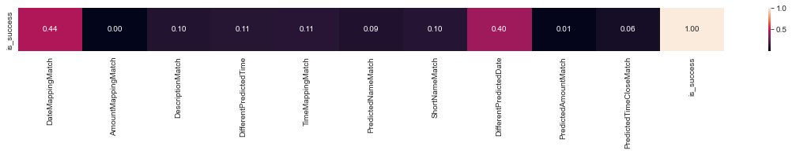

```python
theilu = pd.DataFrame(index=['is_success'],columns=final_df.columns)
columns = final_df.columns
for j in range(0,len(columns)):
    u = theil_u(final_df['is_success'].tolist(),final_df[columns[j]].tolist())
    theilu.loc[:,columns[j]] = u
theilu.fillna(value=np.nan,inplace=True)
plt.figure(figsize=(20,1))
sns.heatmap(theilu,annot=True,fmt='.2f')
plt.show()
```

Can see in above pic the two features (Datemappingmatch and DifferentpredictionDate) are high cross entropy values but as the features are less and value isn't too high like >0.8 so we can keep it

# Hyperparameter Tunning

[figure not shown]

```python
def run_cross_validation_on_trees(X, y, tree_depths, cv=5, scoring='roc_auc'):
    cv_scores_list = []
    cv_scores_std = []
    cv_scores_mean = []
    accuracy_scores = []
    for depth in tree_depths:
        tree_model = DecisionTreeClassifier(max_depth=depth)
        cv_scores = cross_val_score(tree_model, X, y, cv=cv, scoring=scoring)
        cv_scores_list.append(cv_scores)
        cv_scores_mean.append(cv_scores.mean())
        cv_scores_std.append(cv_scores.std())
        accuracy_scores.append(tree_model.fit(X, y).score(X, y))
    cv_scores_mean = np.array(cv_scores_mean)
    cv_scores_std = np.array(cv_scores_std)
    accuracy_scores = np.array(accuracy_scores)
    return cv_scores_mean, cv_scores_std, accuracy_scores

# function for plotting cross-validation results
def plot_cross_validation_on_trees(depths, cv_scores_mean, cv_scores_std, accuracy_scores, title):
    fig, ax = plt.subplots(1,1, figsize=(15,5))
    ax.plot(depths, cv_scores_mean, '-o', label='mean cross-validation ROC-AUC', alpha=0.9)
    ax.fill_between(depths, cv_scores_mean-2*cv_scores_std, cv_scores_mean+2*cv_scores_std, alpha=0.2)
    ylim = plt.ylim()
    ax.plot(depths, accuracy_scores, '-*', label='train ROC-AUC', alpha=0.9)
    ax.set_title(title, fontsize=16)
    ax.set_xlabel('Tree depth', fontsize=14)
    ax.set_ylabel('ROC-AUC', fontsize=14)
    ax.set_ylim(ylim)
    ax.set_xticks(depths)
    ax.legend()

# fitting trees of depth 1 to 24
sm_tree_depths = range(1,10)
sm_cv_scores_mean, sm_cv_scores_std, sm_accuracy_scores = run_cross_validation_on_trees(X_train, y_train, sm_tree_depths)

# plotting accuracy
plot_cross_validation_on_trees(sm_tree_depths, sm_cv_scores_mean, sm_cv_scores_std, sm_accuracy_scores,
                               'ROC-AUC per decision tree depth on training data')
```

# Final Model Apply

```python
tree = DecisionTreeClassifier(max_depth=5, random_state=42)
tree.fit(X_train,y_train)
y_pred = tree.predict(X_test)
ns_probs = [0 for _ in range(len(y_test))]
print("the roc-auc score is ", roc_auc_score(y_test,y_pred))
```

```
the roc-auc score is  0.8071544656146644
```

```
No Skill: ROC AUC=0.500
Decesion Tree: ROC AUC=0.960
```

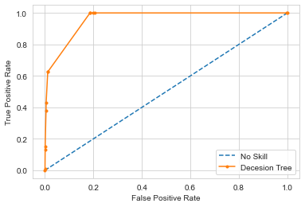

```python
ns_probs = [0 for _ in range(len(y_test))]
lr_probs = tree.predict_proba(X_test)
lr_probs = lr_probs[:, 1]
# calculate scores
ns_auc = roc_auc_score(y_test, ns_probs)
lr_auc = roc_auc_score(y_test, lr_probs)
# summarize scores
print('No Skill: ROC AUC=%.3f' % (ns_auc))
print('Decesion Tree: ROC AUC=%.3f' % (lr_auc))
# calculate roc curves
ns_fpr, ns_tpr, _ = roc_curve(y_test, ns_probs)
lr_fpr, lr_tpr, _ = roc_curve(y_test, lr_probs)
# plot the roc curve for the model
plt.plot(ns_fpr, ns_tpr, linestyle='--', label='No Skill')
plt.plot(lr_fpr, lr_tpr, marker='.', label='Decesion Tree')
# axis labels
plt.xlabel('False Positive Rate')
plt.ylabel('True Positive Rate')
# show the legend
plt.legend()
# show the plot
plt.show()
```

```
Decesion Tree: f1=0.705 auc=0.772
```

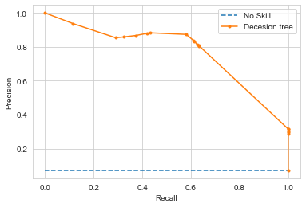

```python
from sklearn.metrics import f1_score
from sklearn.metrics import auc
# lr_precision, lr_recall, _ = precision_recall_curve(y_test, lr_probs)
lr_f1, lr_auc = f1_score(y_test, y_pred), auc(lr_recall, lr_precision)
# summarize scores
print('Decesion Tree: f1=%.3f auc=%.3f' % (lr_f1, lr_auc))
# plot the precision-recall curves
no_skill = len(y_test[y_test==1]) / len(y_test)
plt.plot([0, 1], [no_skill, no_skill], linestyle='--', label='No Skill')
plt.plot(lr_recall, lr_precision, marker='.', label='Decesion tree')
# axis labels
plt.xlabel('Recall')
plt.ylabel('Precision')
# show the legend
plt.legend()
# show the plot
plt.show()
```

```python
cf_matrix = confusion_matrix(y_test, y_pred)
cf_matrix
```

```
array([[3310,   39],
       [  98,  164]], dtype=int64)
```

# Conclusion

As you can see the value of True Positive matching count after my model with test data is 164 . tat means for those receipt ids we can make the default matching value to the actual transaction Id. And we can sort the other values by calculating the Absolute difference between them. For rest which receipt images not matching we can send to Application like "Not Success" once the model o/pis generated

More models can be applied but what really important is the data analysis and feature engineering in it . From the Above diagram you can see The AUC-ROC curve is 0.96, F1 is 0.70 and precesion-recall curve is 0.772 which is quite a good number.